# Lectura e interpretaciòn de datos obtenidos en jornada de control contra la hipertensiòn

```python
import warnings
warnings.simplefilter(action='ignore', category=FutureWarning)
import pandas as pd
from matplotlib import pyplot as plt
import numpy as np

df = pd.read_csv("../data//T.A-F1.csv")
df = df.drop("y", axis=1)
```

### Mediante el presente se realizaran analisis en conjunto con librerias de datos para extraer las respuestas consecuentes a el formulario

#### Las aristas a procesar son las siguentes:

##### -Posee algún problema asociado a su tensión arterial?

##### -Tiene antecedentes familiares con problemas asociados a su tensión arterial?

##### -En este momento esta llevando a cabo algún tratamiento indicado por un profesional de la salud para mantener controlada su tensión arterial?

##### -En caso de tener recetada medicación, indique en qué grupo entra.

##### -Puede disponer de la medicación recetada?

##### -Posee los recursos económicos para abastecerse de esta?

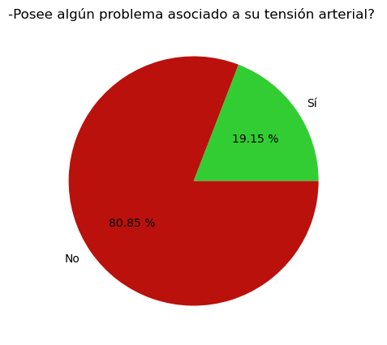

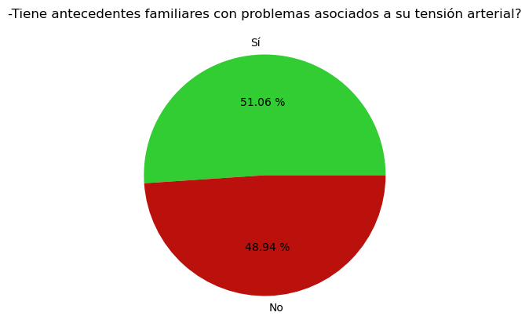

```python
s = df.loc[df["F1"] == "Sí"].count()[0]
n = df.loc[df["F1"] == "No"].count()[0]
labels = ["Sí", "No"]
colors = ["#32cd32", "#BA110C"]
plt.figure(figsize=(8,5))
plt.title("-Posee algún problema asociado a su tensión arterial? ")
plt.pie([s, n], labels=labels, colors=colors, autopct="%.2f %%")
plt.show()

s = df.loc[df["F2"] == "Sí"].count()[0]
n = df.loc[df["F2"] == "No"].count()[0]
labels = ["Sí", "No"]
colors = ["#32cd32", "#BA110C"]
plt.figure(figsize=(8,5))
plt.title("-Tiene antecedentes familiares con problemas asociados a su tensión arterial?")
plt.pie([s, n], labels=labels, colors=colors, autopct="%.2f %%")
plt.show()
```

##### Mediante los siguientes graficos podemos preguntarnos tambien que porcentaje de los que si tienen problematicas asociadas tienen relacion congenita

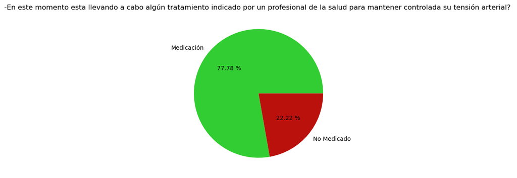

```python
htp = df.loc[df["F1"] == "Sí"]
s = htp.loc[df["F3"] == "Medicación"].count()[0]
n = htp.loc[df["F3"] == "Ninguna"].count()[0]
labels = ["Medicación", "No Medicado"]
colors = ["#32cd32", "#BA110C"]
plt.figure(figsize=(8,5))
plt.title("-En este momento esta llevando a cabo algún tratamiento indicado por un profesional de la salud para mantener controlada su tensión arterial? ")
plt.pie([s, n], labels=labels, colors=colors, autopct="%.2f %%")
plt.show()
```

##### Traducimos el 22.22% en 2 personas de los encuestados que no se tratan a nivel clinico por su hipertension declarada

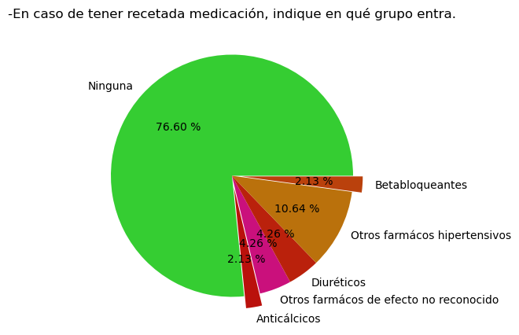

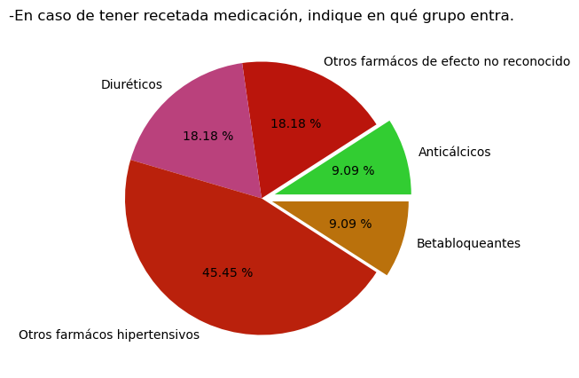

```python
ca = df.loc[df["F4"] == "Ninguna"].count()[0]
cb = df.loc[df["F4"] == "Anticálcicos"].count()[0]
cc = df.loc[df["F4"] == "Otros farmácos de efecto no reconocido"].count()[0]
cd = df.loc[df["F4"] == "Diuréticos"].count()[0]
ce = df.loc[df["F4"] == "Otros farmácos hipertensivos"].count()[0]
cf = df.loc[df["F4"] == "Betabloqueantes"].count()[0]
explode = (0, 0.1, 0, 0, 0, 0.08)
labels = ["Ninguna", "Anticálcicos", "Otros farmácos de efecto no reconocido", "Diuréticos", "Otros farmácos hipertensivos", "Betabloqueantes"]
colors = ["#35cd32", "#BA110C", "#CA107C", "#BA210C", "#BA710C", "#BA410C"]
plt.figure(figsize=(8,5))
plt.title("-En caso de tener recetada medicación, indique en qué grupo entra.")
plt.pie([ca, cb, cc, cd, ce, cf], labels=labels, colors=colors, explode=explode, autopct="%.2f %%")
plt.show()

cb = df.loc[df["F4"] == "Anticálcicos"].count()[0]
cc = df.loc[df["F4"] == "Otros farmácos de efecto no reconocido"].count()[0]
cd = df.loc[df["F4"] == "Diuréticos"].count()[0]
ce = df.loc[df["F4"] == "Otros farmácos hipertensivos"].count()[0]
cf = df.loc[df["F4"] == "Betabloqueantes"].count()[0]
explode = (0.1, 0, 0, 0, 0.08)
labels = ["Anticálcicos", "Otros farmácos de efecto no reconocido", "Diuréticos", "Otros farmácos hipertensivos", "Betabloqueantes"]
colors = ["#32cd32", "#BA150C", "#BA417C", "#BA210C", "#BA710C", "#BA410C"]
plt.figure(figsize=(8,5))
plt.title("-En caso de tener recetada medicación, indique en qué grupo entra.")
plt.pie([cb, cc, cd, ce, cf], labels=labels, colors=colors, explode=explode, autopct="%.2f %%")
plt.show()
```

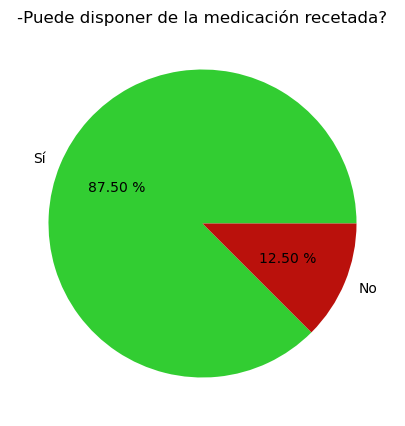

```python
htp = df.loc[df["F1"] == "Sí"]
s = htp.loc[df["F5"] == "Sí"].count()[0]
n = htp.loc[df["F5"] == "No"].count()[0]
labels = ["Sí", "No"]
colors = ["#32cd32", "#BA110C"]
plt.figure(figsize=(8,5))
plt.title("-Puede disponer de la medicación recetada?")
plt.pie([s, n], labels=labels, colors=colors, autopct="%.2f %%")
plt.show()
```

##### Este grafico tambien ampara la totalidad de los positivos en hipertensíon arterial

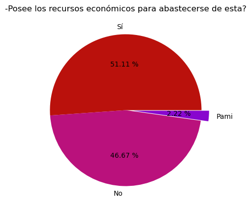

```python
cb = df.loc[df["F6"] == "Sí"].count()[0]
cc = df.loc[df["F6"] == "No"].count()[0]
cd = df.loc[df["F6"] == "Pami"].count()[0]
explode = (0, 0, 0.1)
labels = ["Sí", "No", "Pami"]
colors = ["#BA110C", "#BA117C", "#8806CE"]
plt.figure(figsize=(8,5))
plt.title("-Posee los recursos económicos para abastecerse de esta?")
plt.pie([cb, cc, cd], labels=labels, colors=colors, explode=explode, autopct="%.2f %%")
plt.show()
```

##### Y por ultimo este grafico representa la facilidad al acceso de los medicamentos por parte de los encuestados en su totalidad

```python
df
```

|  | F1 | F2 | F3 | F4 | F5 | F6 |
| --- | --- | --- | --- | --- | --- | --- |
| 0 | Sí | Sí | Ninguna | Ninguna | Ninguna | Ninguna |
| 1 | No | Sí | Ninguna | Ninguna | Ninguna | Ninguna |
| 2 | No | Sí | Ninguna | Ninguna | No | Sí |
| 3 | No | Sí | Ninguna | Ninguna | Sí | Sí |
| 4 | No | No | Ninguna | Ninguna | No | No |
| 5 | No | No | Ninguna | Ninguna | No | No |
| 6 | Sí | Sí | Medicación | Anticálcicos | Sí | Sí |
| 7 | No | Sí | Ninguna | Ninguna | No | Sí |
| 8 | No | No | Ninguna | Ninguna | No | Sí |
| 9 | No | Sí | Ninguna | Ninguna | Sí | Sí |
| 10 | Sí | Sí | Ninguna | Ninguna | No | No |
| 11 | No | Sí | Ninguna | Ninguna | Sí | Sí |
| 12 | No | No | Ninguna | Ninguna | Sí | Sí |
| 13 | Sí | Sí | Medicación | Otros farmácos hipertensivos | Sí | Sí |
| 14 | No | Sí | Ninguna | Ninguna | No | No |
| 15 | No | Sí | Ninguna | Ninguna | Sí | Sí |
| 16 | No | No | Ninguna | Ninguna | Sí | Sí |
| 17 | No | Sí | Ninguna | Ninguna | No | Sí |
| 18 | No | Sí | Medicación | Otros farmácos hipertensivos | Sí | Pami |
| 19 | No | Sí | Ninguna | Ninguna | No | Sí |
| 20 | No | No | Ninguna | Ninguna | No | No |
| 21 | No | No | Ninguna | Ninguna | No | No |
| 22 | No | Sí | Ninguna | Ninguna | No | No |
| 23 | Sí | Sí | Medicación | Otros farmácos hipertensivos | Sí | Sí |
| 24 | No | Sí | Ninguna | Ninguna | No | No |
| 25 | No | No | Ninguna | Ninguna | No | No |
| 26 | No | No | Ninguna | Ninguna | No | No |
| 27 | No | Sí | Ninguna | Ninguna | No | No |
| 28 | No | No | Ninguna | Ninguna | No | No |
| 29 | No | No | Ninguna | Ninguna | No | No |
| 30 | No | No | Ninguna | Ninguna | No | No |
| 31 | No | Sí | Ninguna | Ninguna | No | No |
| 32 | Sí | No | Medicación | Otros farmácos hipertensivos | Sí | Sí |
| 33 | No | Sí | Ninguna | Ninguna | Sí | Sí |
| 34 | Sí | Sí | Medicación | Otros farmácos de efecto no reconocido | Sí | Sí |
| 35 | No | No | Medicación | Diuréticos | Sí | Sí |
| 36 | Sí | No | Medicación | Otros farmácos hipertensivos | Sí | Sí |
| 37 | No | No | Ninguna | Ninguna | No | No |
| 38 | No | No | Ninguna | Ninguna | No | No |
| 39 | No | Sí | Medicación | Otros farmácos de efecto no reconocido | No | Sí |
| 40 | No | No | Medicación | Betabloqueantes | Sí | Sí |
| 41 | Sí | No | Medicación | Diuréticos | Sí | Sí |
| 42 | No | Sí | Ninguna | Ninguna | Sí | Sí |
| 43 | No | No | Ninguna | Ninguna | No | No |
| 44 | No | No | Ninguna | Ninguna | No | No |
| 45 | No | No | Ninguna | Ninguna | No | No |
| 46 | No | No | Ninguna | Ninguna | No | No |

#### Base de la cual se extrajeros los datos correspondientes para el informe, formada en base a la encuesta realizada en forms, basada a su vez en la encuesta de la OPS